# NYPD Shooting Incident Report

Q Arif

8/15/2021

```
## Google's Terms of Service: https://cloud.google.com/maps-platform/terms/.
```

## NYPD Shooting Incident Project Summary

In this report, we will take a look at the shooting Incidents happened between 2006 and 2020 data from NYPD (https://catalog.data.gov/dataset). We will look at the historic trend of shooting and where they are concentrated. The Covid-19 has caused countries to lock down and economies to slow. People have lost jobs and families due to the pandemic. Between dwindling savings and an invisible killer in the air, cities have seen a rise on violent crime in 2020. The question to answer is whether the Covid-19 pandemic has lead to increase in violent crime?

## Shooting Incidents in New York over the years

### What are my assumptions?

A shooting incident is a violent crime against a victim that may have resulted injury or death. The NYPD categorizing and reports this incident type consistently over the years.

Not all incidents that happened would have reported but we are going to assume that the rate of incident reporting are similar between 2006 and 2020.

### What are my potential biases?

1. Data came from a single source with no cross-checking. This could disconnect the analysis from reality.
2. An overall negative/pessimistic outlook caused by the pandemic.
3. Not familiar with American culture and way of life.

## Shooting Incidents between 2006 and 2020

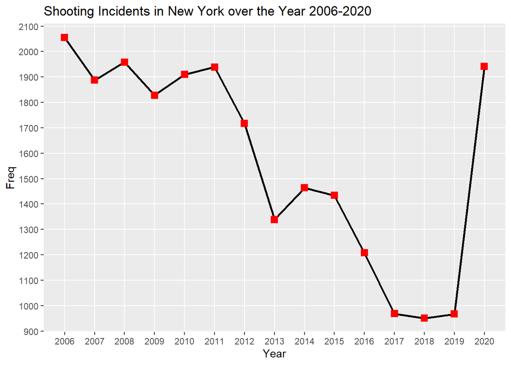

```r
#plot graph 1
ggplot(data=NYPD_data_model, aes(x=Year,y=Freq)) +
             geom_line(size=1) + geom_point(shape=15, colour='red', fill='black', size=3) +
             scale_y_continuous(breaks=seq(900,2100,by=100)) +
             scale_x_continuous(breaks=2006:2020) +
             theme(axis.title.x=element_text(), axis.title.y=element_text(),
                   panel.grid.minor = element_blank()) +
             ggtitle("Shooting Incidents in New York over the Year 2006-2020")
```

### Analysing the Data

Since 2006, the shooting incidents have gradually decreases over 15 years from over 2000 incidents in 2006 to less than 1000 incidents in 2019. New York was relatively safe until the start of pandemic in 2020. In 2020, The number of shooting incidents doubled the previous year of 2019. A crime heatmap shows where the incidents are occurring. Notably, a large concentration of incidents in Brooklyn collectively over 15 years.

### Conclusion

To answer the question we asked, we will also have to look at New York city policies and news for Covid-19 to the incidents to see if any pattern arise and to make sense of it.

[figure not shown]

```r
#plot graph 2
ggmap(NY_map) +
  stat_density2d(data = NYPD_Data, aes(x = Longitude, y = Latitude, fill = ..density..), geom = 'tile', contour = F, alpha = .5) +
  scale_fill_viridis(option = 'inferno') +
  labs(title = str_c('Brooklyn has the highest concentration of \nshooting incidents')
       ,fill = str_c('Number of', '\nshooting incidents')
       ) +
  theme(text = element_text(color = "#444444")
        ,plot.title = element_text(size = 18, face = 'bold')
        ,plot.subtitle = element_text(size = 10)
        ,axis.text = element_blank()
        ,axis.title = element_blank()
        ,axis.ticks = element_blank()
        )
```

Resources and References: 1. . Kahle and H. Wickham. ggmap: Spatial Visualization with ggplot2. The R Journal, 5(1), 144-161. URL http://journal.r-project.org/archive/2013-1/kahle-wickham.pdf